# Red wine (Vinho Verde) quality exploration by Sebastien LOPATOWSKI

# Univariate Plots Section

```
## [1] 1599   13
```

```
##  [1] "X"                    "fixed.acidity"        "volatile.acidity"
##  [4] "citric.acid"          "residual.sugar"       "chlorides"
##  [7] "free.sulfur.dioxide"  "total.sulfur.dioxide" "density"
## [10] "pH"                   "sulphates"            "alcohol"
## [13] "quality"
```

```
## 'data.frame':    1599 obs. of  13 variables:
##  $ X                   : int  1 2 3 4 5 6 7 8 9 10 ...
##  $ fixed.acidity       : num  7.4 7.8 7.8 11.2 7.4 7.4 7.9 7.3 7.8 7.5 ...
##  $ volatile.acidity    : num  0.7 0.88 0.76 0.28 0.7 0.66 0.6 0.65 0.58 0.5 ...
##  $ citric.acid         : num  0 0 0.04 0.56 0 0 0.06 0 0.02 0.36 ...
##  $ residual.sugar      : num  1.9 2.6 2.3 1.9 1.9 1.8 1.6 1.2 2 6.1 ...
##  $ chlorides           : num  0.076 0.098 0.092 0.075 0.076 0.075 0.069 0.065 0.073 0.071 ...
##  $ free.sulfur.dioxide : num  11 25 15 17 11 13 15 15 9 17 ...
##  $ total.sulfur.dioxide: num  34 67 54 60 34 40 59 21 18 102 ...
##  $ density             : num  0.998 0.997 0.997 0.998 0.998 ...
##  $ pH                  : num  3.51 3.2 3.26 3.16 3.51 3.51 3.3 3.39 3.36 3.35 ...
##  $ sulphates           : num  0.56 0.68 0.65 0.58 0.56 0.56 0.46 0.47 0.57 0.8 ...
##  $ alcohol             : num  9.4 9.8 9.8 9.8 9.4 9.4 9.4 10 9.5 10.5 ...
##  $ quality             : int  5 5 5 6 5 5 5 7 7 5 ...
```

```
##        X          fixed.acidity   volatile.acidity  citric.acid
##  Min.   :   1.0   Min.   : 4.60   Min.   :0.1200   Min.   :0.000
##  1st Qu.: 400.5   1st Qu.: 7.10   1st Qu.:0.3900   1st Qu.:0.090
##  Median : 800.0   Median : 7.90   Median :0.5200   Median :0.260
##  Mean   : 800.0   Mean   : 8.32   Mean   :0.5278   Mean   :0.271
##  3rd Qu.:1199.5   3rd Qu.: 9.20   3rd Qu.:0.6400   3rd Qu.:0.420
##  Max.   :1599.0   Max.   :15.90   Max.   :1.5800   Max.   :1.000
##  residual.sugar     chlorides       free.sulfur.dioxide
##  Min.   : 0.900   Min.   :0.01200   Min.   : 1.00
##  1st Qu.: 1.900   1st Qu.:0.07000   1st Qu.: 7.00
##  Median : 2.200   Median :0.07900   Median :14.00
##  Mean   : 2.539   Mean   :0.08747   Mean   :15.87
##  3rd Qu.: 2.600   3rd Qu.:0.09000   3rd Qu.:21.00
##  Max.   :15.500   Max.   :0.61100   Max.   :72.00
##  total.sulfur.dioxide    density             pH          sulphates
##  Min.   :  6.00       Min.   :0.9901   Min.   :2.740   Min.   :0.3300
##  1st Qu.: 22.00       1st Qu.:0.9956   1st Qu.:3.210   1st Qu.:0.5500
##  Median : 38.00       Median :0.9968   Median :3.310   Median :0.6200
##  Mean   : 46.47       Mean   :0.9967   Mean   :3.311   Mean   :0.6581
##  3rd Qu.: 62.00       3rd Qu.:0.9978   3rd Qu.:3.400   3rd Qu.:0.7300
##  Max.   :289.00       Max.   :1.0037   Max.   :4.010   Max.   :2.0000
##     alcohol         quality
##  Min.   : 8.40   Min.   :3.000
##  1st Qu.: 9.50   1st Qu.:5.000
##  Median :10.20   Median :6.000
##  Mean   :10.42   Mean   :5.636
##  3rd Qu.:11.10   3rd Qu.:6.000
##  Max.   :14.90   Max.   :8.000
```

```
## General description of the dataset
```

```
##
##   3   4   5   6   7   8
##  10  53 681 638 199  18
```

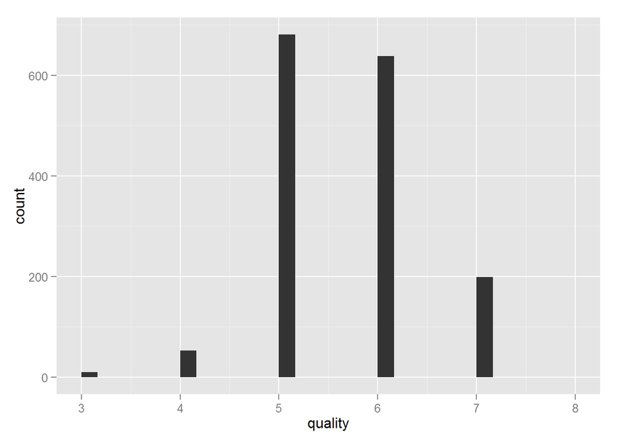

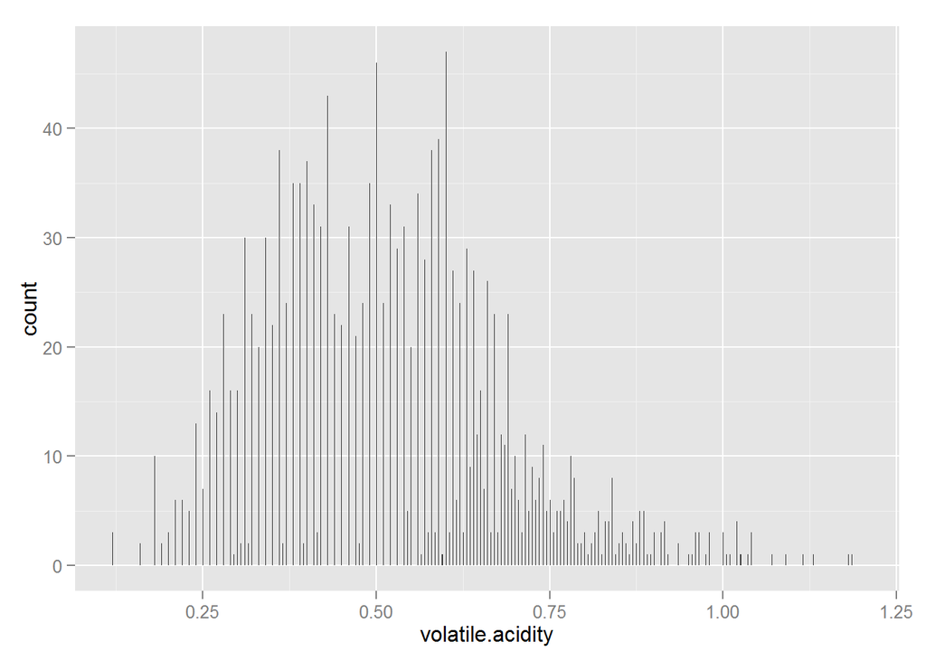

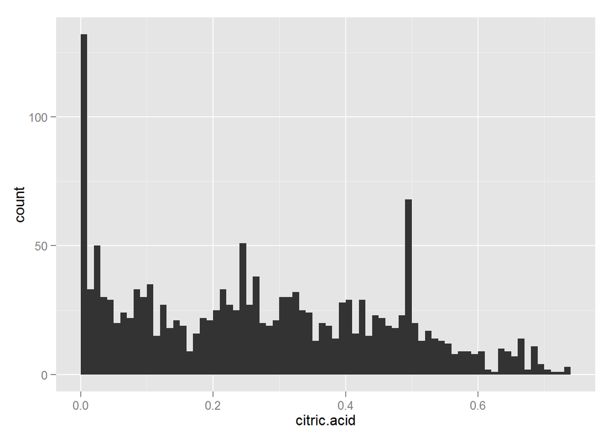

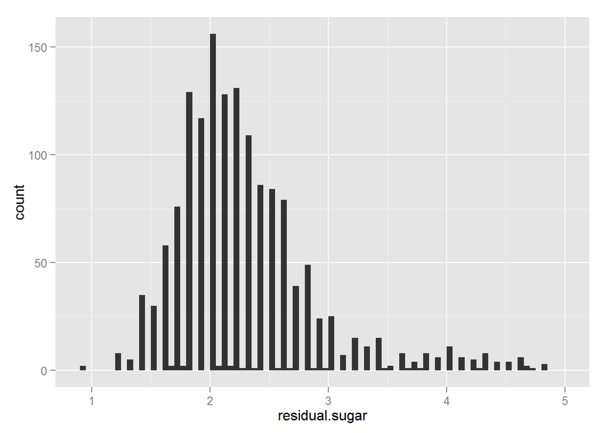

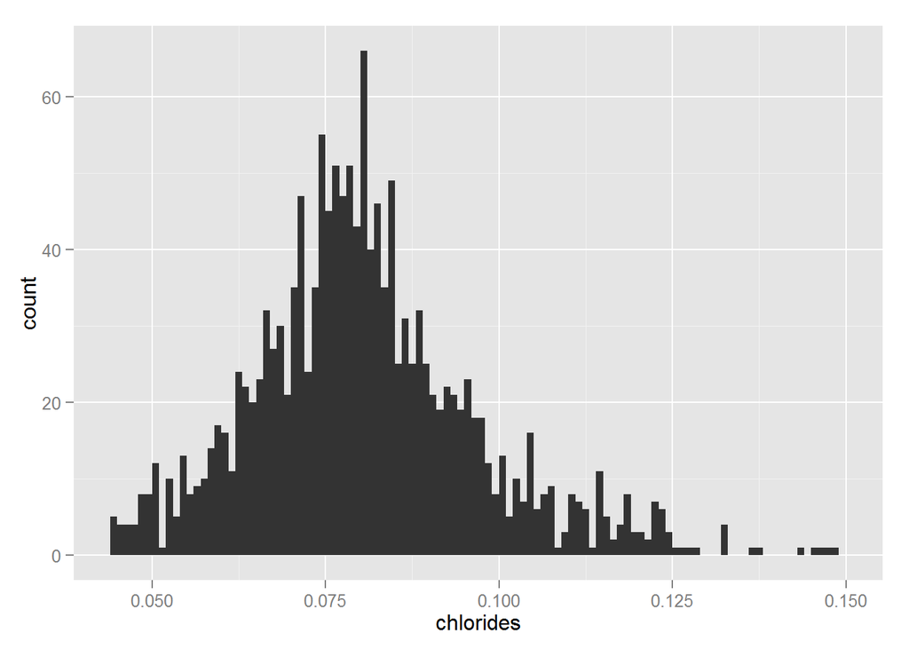

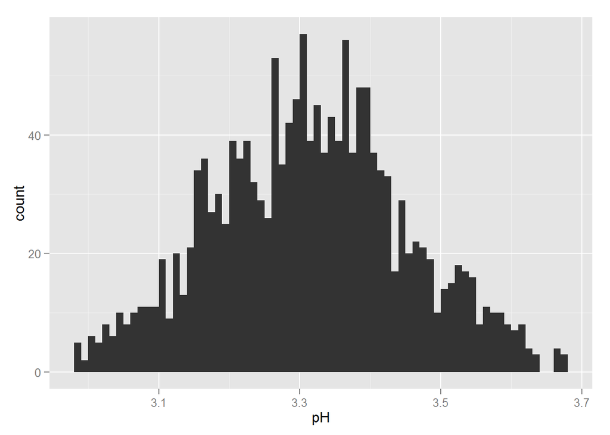

```
##
##              8.4              8.5              8.7              8.8
##                2                1                2                2
##                9             9.05              9.1              9.2
##               30                1               23               72
## 9.23333333333333             9.25              9.3              9.4
##                1                1               59              103
##              9.5             9.55 9.56666666666667              9.6
##              139                2                1               59
##              9.7              9.8              9.9             9.95
##               54               78               49                1
##               10 10.0333333333333             10.1             10.2
##               67                2               47               46
##             10.3             10.4             10.5            10.55
##               33               41               67                2
##             10.6             10.7            10.75             10.8
##               28               27                1               42
##             10.9               11 11.0666666666667             11.1
##               49               59                1               27
##             11.2             11.3             11.4             11.5
##               36               32               32               30
##             11.6             11.7             11.8             11.9
##               15               23               29               20
##            11.95               12             12.1             12.2
##                1               21               13               12
##             12.3             12.4             12.5             12.6
##               12               13               21                6
##             12.7             12.8             12.9               13
##                9               17                9                6
##             13.1             13.2             13.3             13.4
##                2                1                3                3
##             13.5 13.5666666666667             13.6               14
##                1                1                4                7
##             14.9
##                1
```

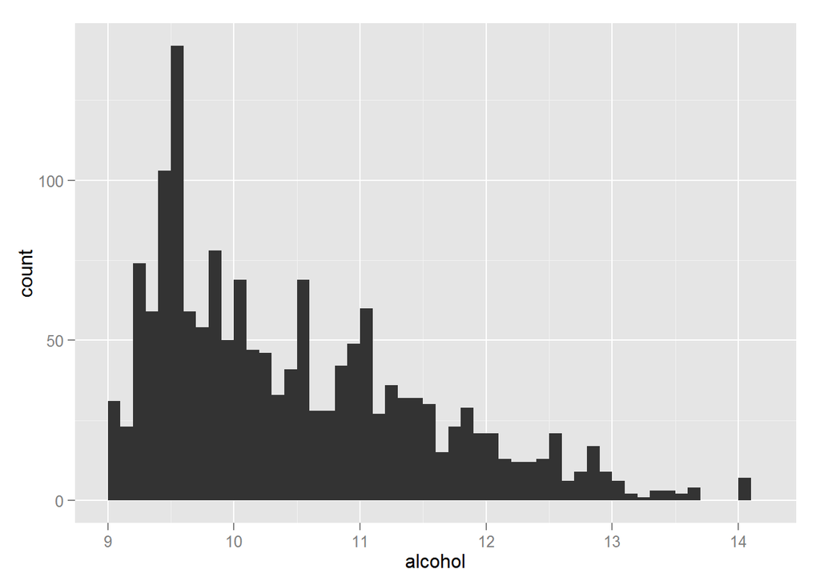

```
## Simple plot with important variables
```

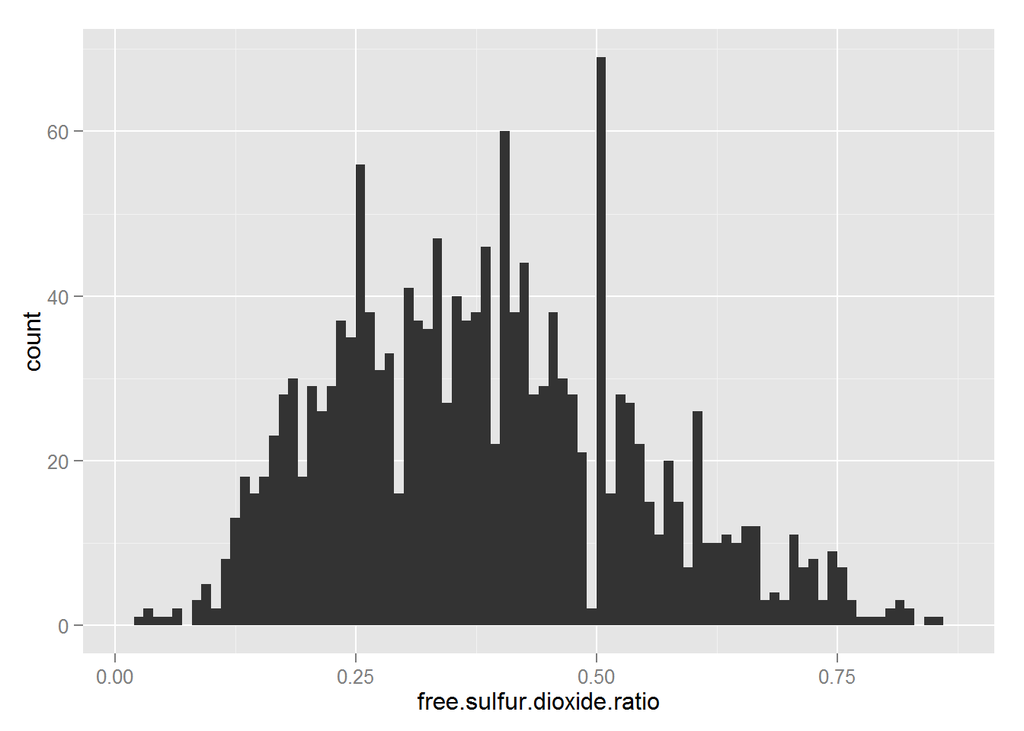

# Univariate Analysis

### What is the structure of your dataset?

There are 1599 wines in the dataset with 13 features (X (wine id), fixed acidity, volatile acidity, citric acid, residual sugar, chlorides, free sulfur dioxide, total sulfur dioxide, density, pH, sulphates, alcohol, quality).

Other observations: The wines are quite correct in terme of quality (score between 0 and 10) with median 6, min 3 and max 8. The median alcohol is 10.20. Most wines have a pH between 3 and 3.5.

### What is/are the main feature(s) of interest in your dataset?

The main features in the data set are quality, volatile acidity, citric acid, residual sugar, chlorides and alcohol. I’d like to determine which features are best for predicting the quality of a wine.

### What other features in the dataset do you think will help support your investigation into your feature(s) of interest?

Fixed acidity, free sulfur dioxide, total sulfur dioxide, density, pH and sulphates help me indirectly to find some relation with the quality of the wine.

### Did you create any new variables from existing variables in the dataset?

I created a variable for the ratio of free sulfur dioxide by total sulfur dioxide. With this variable we can understand more the quantity of the free sulfur dioxide in the wine.

### Of the features you investigated, were there any unusual distributions? Did you perform any operations on the data to tidy, adjust, or change the form of the data? If so, why did you do this?

I used the limit and binwidth command to set the position where the data are important and binwidth to find some unusual issues.

# Bivariate Plots Section

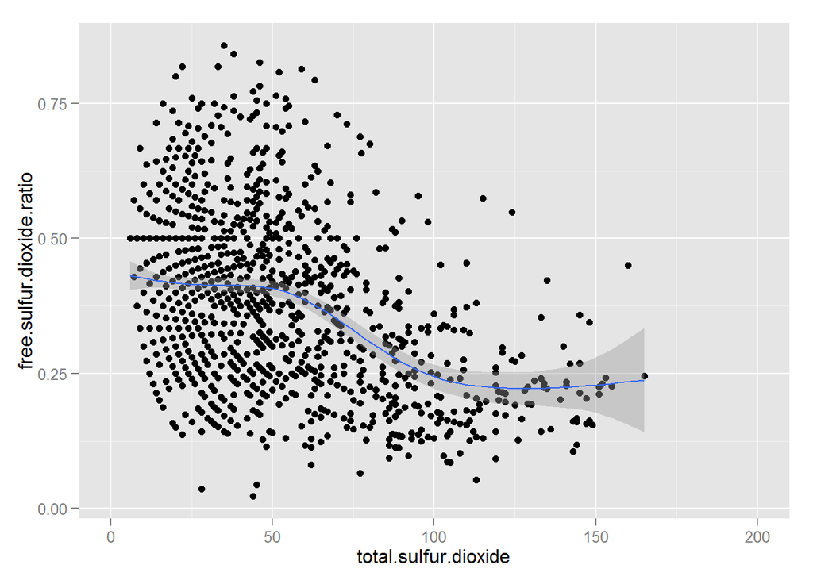

[figure not shown]

```
## Matrix plots of the dataset
```

```
##
##  Pearson's product-moment correlation
##
## data:  citric.acid and fixed.acidity
## t = 36.2341, df = 1597, p-value < 2.2e-16
## alternative hypothesis: true correlation is not equal to 0
## 95 percent confidence interval:
##  0.6438839 0.6977493
## sample estimates:
##       cor
## 0.6717034
```

```
## Good correlation between citric acid and fixed acidity
```

```
##
##  Pearson's product-moment correlation
##
## data:  density and fixed.acidity
## t = 35.8771, df = 1597, p-value < 2.2e-16
## alternative hypothesis: true correlation is not equal to 0
## 95 percent confidence interval:
##  0.6399847 0.6943302
## sample estimates:
##       cor
## 0.6680473
```

```
## Good correlation between density and fixed acidity
```

```
##
##  Pearson's product-moment correlation
##
## data:  pH and fixed.acidity
## t = -37.3659, df = 1597, p-value < 2.2e-16
## alternative hypothesis: true correlation is not equal to 0
## 95 percent confidence interval:
##  -0.7082857 -0.6559174
## sample estimates:
##        cor
## -0.6829782
```

```
## Good correlation between pH and fixed.acidity
```

```
##
##  Pearson's product-moment correlation
##
## data:  density and residual.sugar
## t = 15.189, df = 1597, p-value < 2.2e-16
## alternative hypothesis: true correlation is not equal to 0
## 95 percent confidence interval:
##  0.3116908 0.3973835
## sample estimates:
##       cor
## 0.3552834
```

```
## Correlation between density and residual.sugar
```

```
##
##  Pearson's product-moment correlation
##
## data:  density and alcohol
## t = -22.8382, df = 1597, p-value < 2.2e-16
## alternative hypothesis: true correlation is not equal to 0
## 95 percent confidence interval:
##  -0.5322547 -0.4583061
## sample estimates:
##        cor
## -0.4961798
```

```
## Correlation between density and alcohol
```

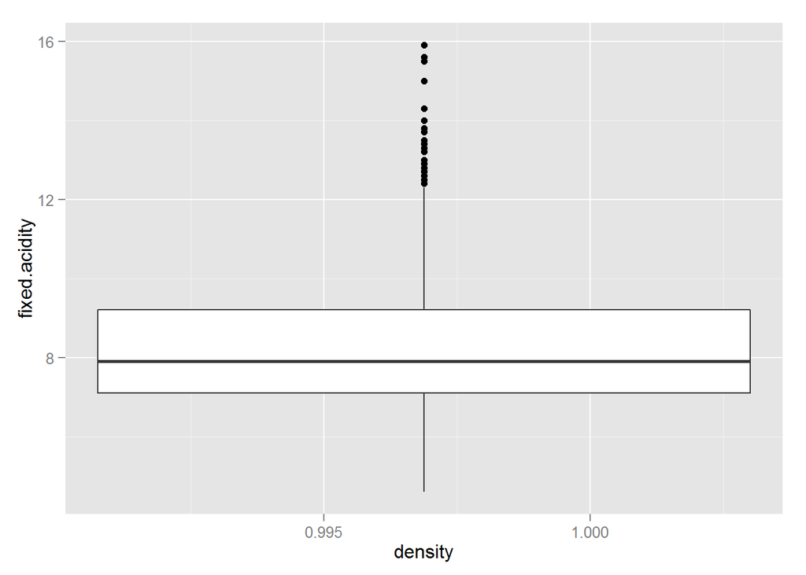

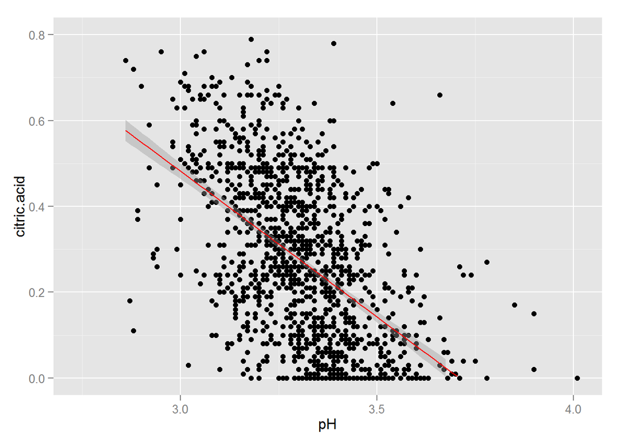

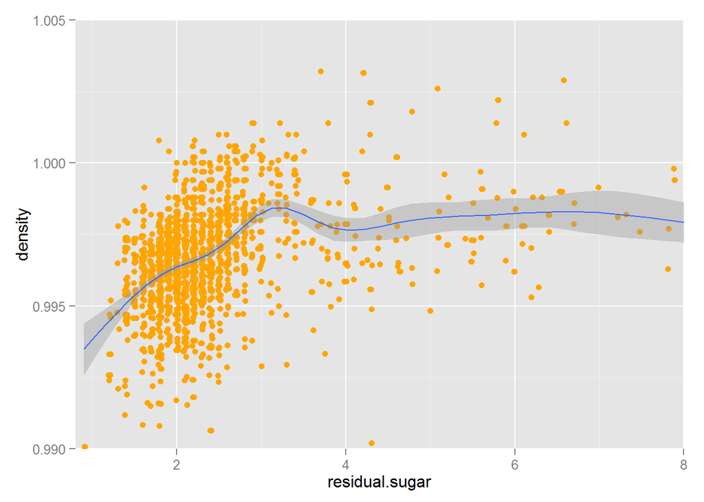

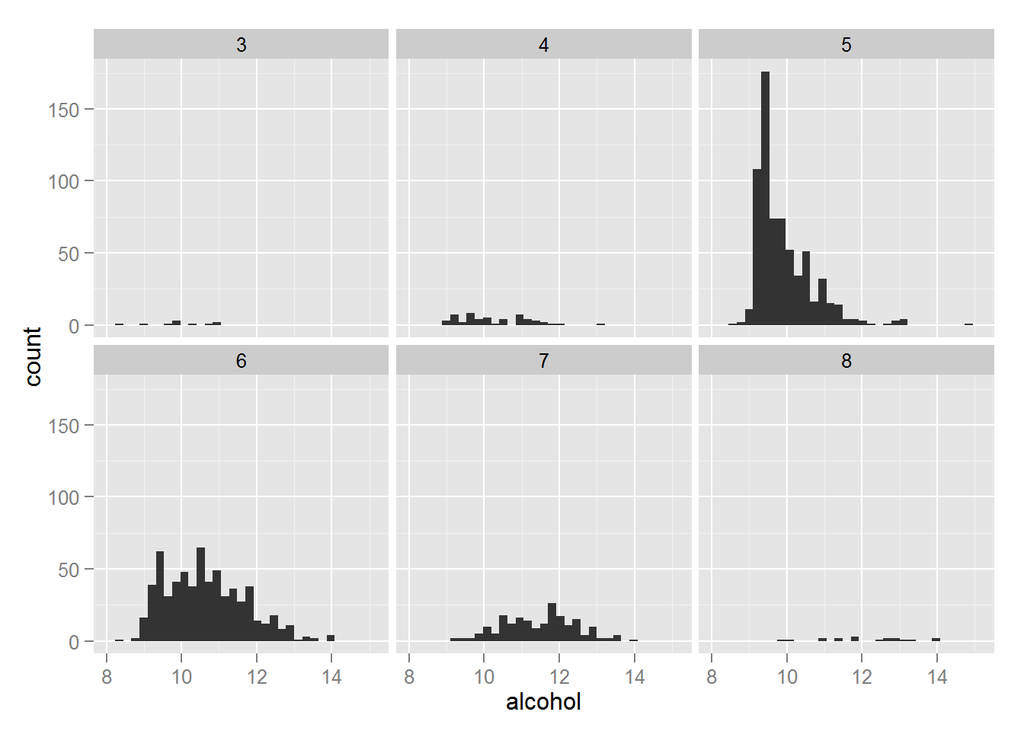

```
## Alcohol by wine quality
```

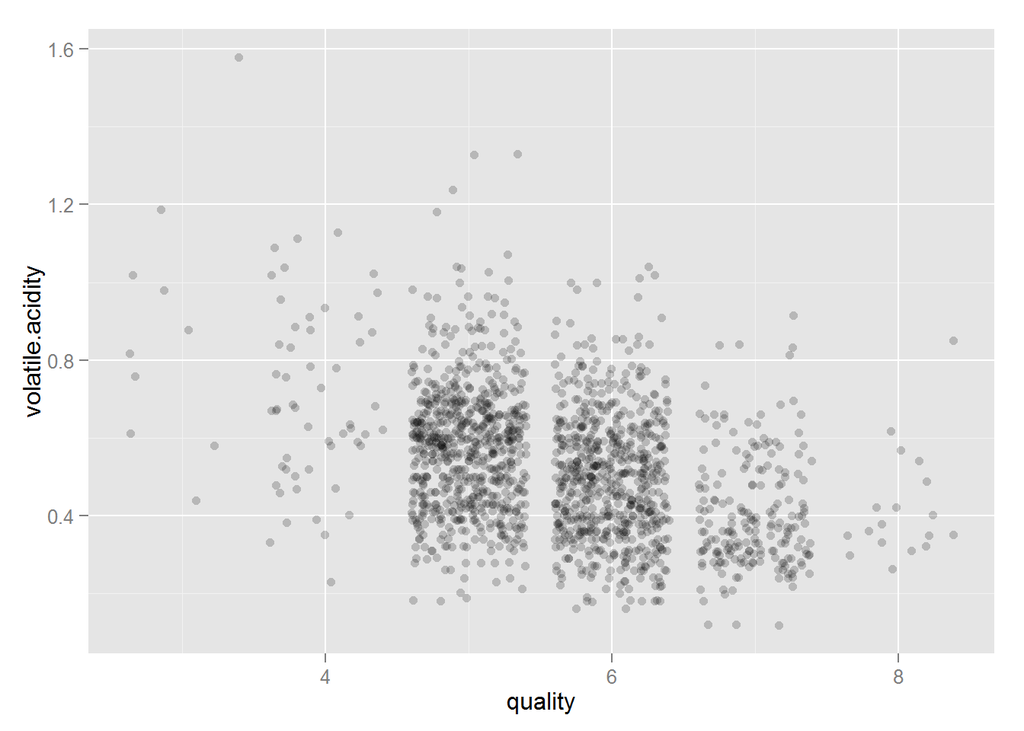

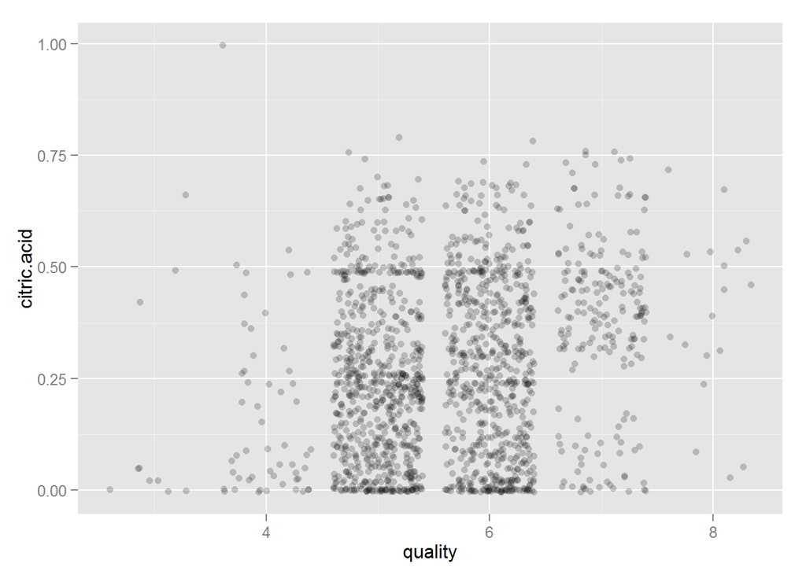

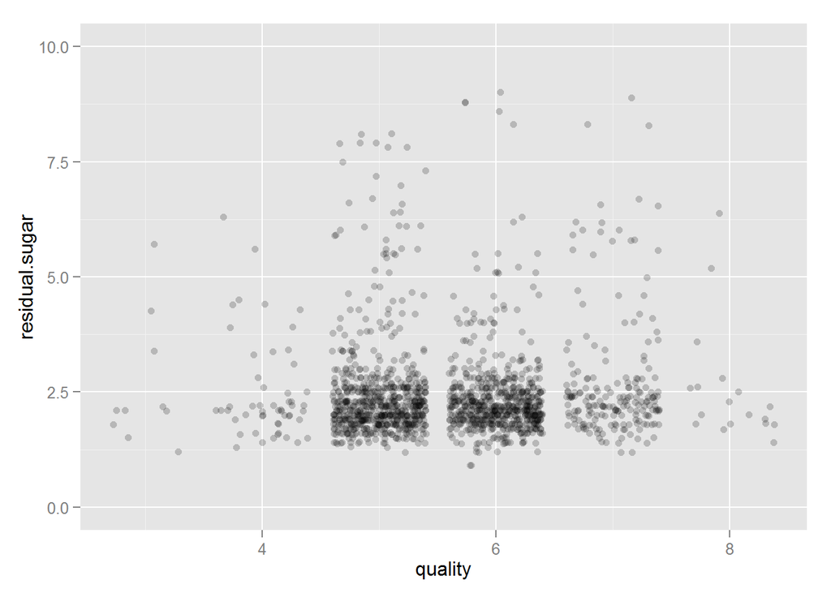

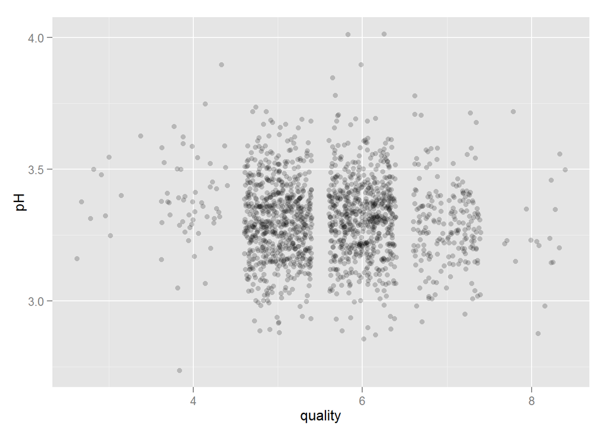

```
## Variables by wine quality
```

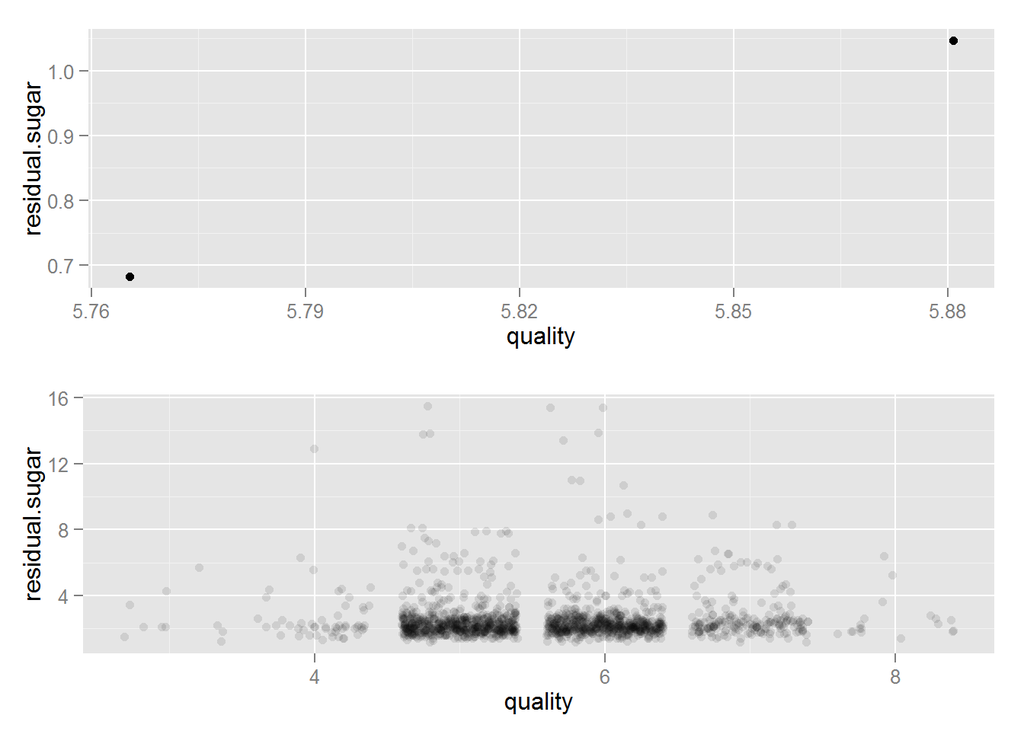

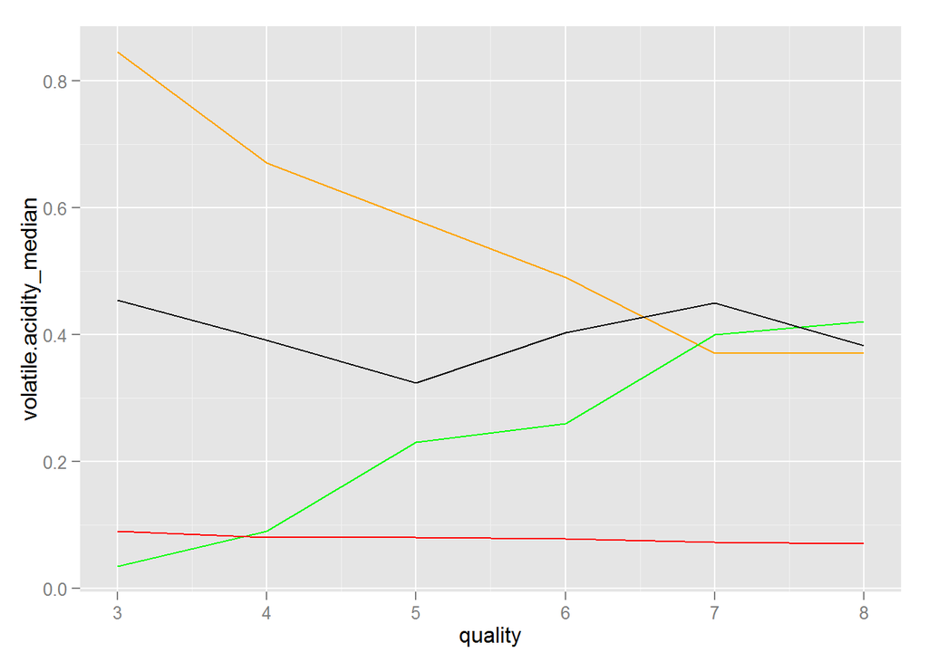

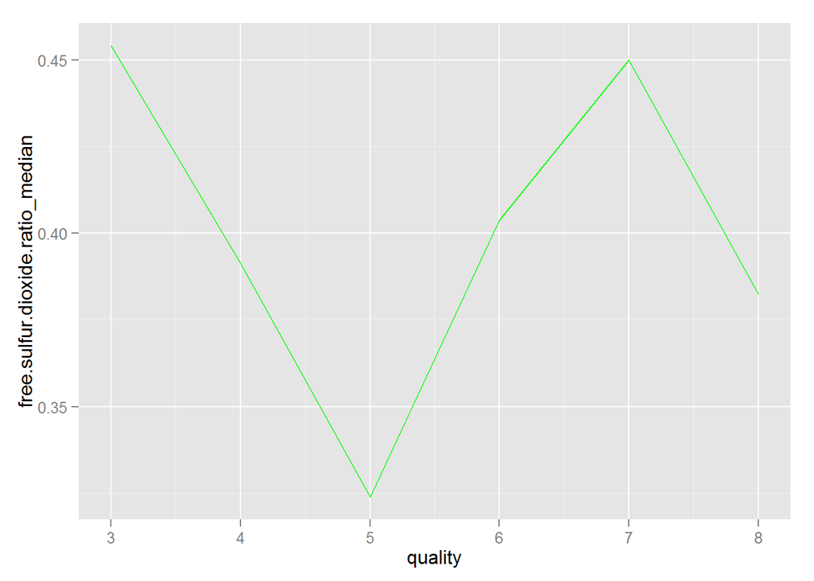

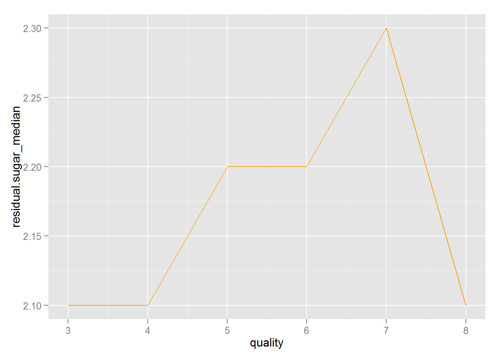

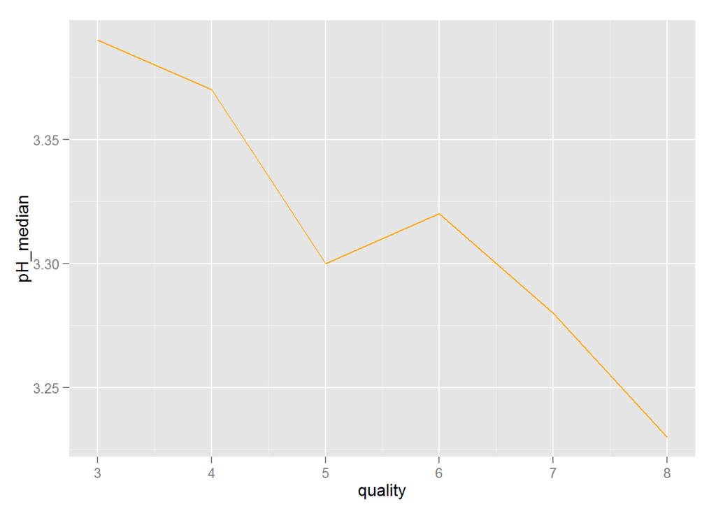

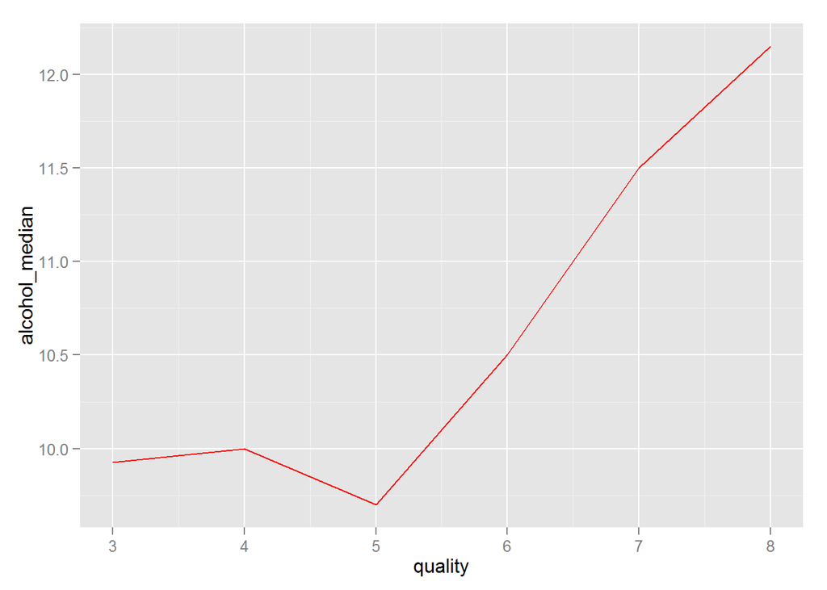

```
## Several plots by quality evolution
```